# Homework #3

Keene Morrow, Madeline Oliver, & Minerva Ringland

5/13/2020

This system further merits attention as a matter of environmental justice. On a global scale, the countries most at risk of increasing extreme heat-based mortality are developing nations without the resources or infrastructure to develop adaptive measures. (There is also the unfortunate paradox that cooling technology is energy-intensive and often relies on fossil fuels, further contributing to GHG emissions and exacerbating the root cause of rising temperatures.) On a more local scale, individuals most at risk are those who perform strenuous activities, work outdoors, cannot afford air conditioning, are homeless, etc.

The threshold value commonly used for human survivability is 35°C wet bulb temperature.(Pal & Eltahir 2015 https://www.nature.com/articles/nclimate2833) Practically however, it is easier to collect dry air temperature and relative humidity data. Public health studies tend to use apparent temperature (AT), Humidex (HI), or heat index (HX) to calculate a “feels like” temperature proxy for mortality, as discussed in Sanderson et al.’s 2017 review of 63 studies on heat wave mortality.

Variables needed: t_air - air temperature (in celsius) t_d - dew point temperature (in celsius) rh - relative humidity (%)

“Daily mean and daily maximum temperatures have been used to calculate a corresponding daily mean and daily maximum apparent temperature.”

Variables derived:

1. Dew point temperature Using the formula from http://bmcnoldy.rsmas.miami.edu/Humidity.html: TD: =243.04*(LN(RH/100)+((17.625*T)/(243.04+T)))/(17.625-LN(RH/100)-((17.625*T)/(243.04+T)))

Reference: Alduchov, O. A., and R. E. Eskridge, 1996: Improved Magnus’ form approximation of saturation vapor pressure. J. Appl. Meteor., 35, 601–609.

2. Apparent temperature (at) at = -2.653 + (0.994 * t_air) + (0.0153 * (t_d)^2)
3. Humidex (hx)

3.a. vapor pressure of water v (in hPa)

v = (6.112 × 10ˆ(7.5 * t_air/(237.7 + t_air)) * rh/100)

3.b. humidex hx = t_air + (v-10) * (5/9)

“A Humidex of less than 29 means no discomfort; 30 to 39 some discomfort; 40 to 45 great discomfort and avoid exertion; and above 45 is dangerous, heat stroke is possible.”

Both #2 and #3 equations are from https://journals.plos.org/plosone/article/file?id=10.1371/journal.pone.0180369.s005&type=supplementary

Because these equations are based on simple physical properties of temperature and humidity, we do not expect them to be subject to uncertainty or revision. As indices, the values calculated are expected to increase with climate change but the underlying relationships shouldn’t change.

The first climate model used is CNRM-CM5, which couples atmospheric, sea, land surface, and sea ice climate models into a single GCM. It was developed jointly by CNRM-GAME (Centre National de Recherches Météorologiques—Groupe d’études de l’Atmosphère Météorologique) and Cerfacs (Centre Européen de Recherche et de Formation Avancée) to be used for phase 5 of the Coupled Model Intercomparison Project (CMIP5).

The second climate model used is HadGEM2-ES, a coupled GCM published by the Met Office in the UK. The author of the literature review is also affiliated with the Met Office, so we thought it might be interesting to see how publications from the same office line up. HadGEM2 models couple atmosphere, ocean, and “earth system” components (no sea ice).

The third climate model used is CanESM2, a Canadian GCM that couples atmosphere-ocean model CanCM4 with terrestrial carbon model (CTEM) and an ocean carbon model (CMOC).

(These three were the only ones that contained RH data).

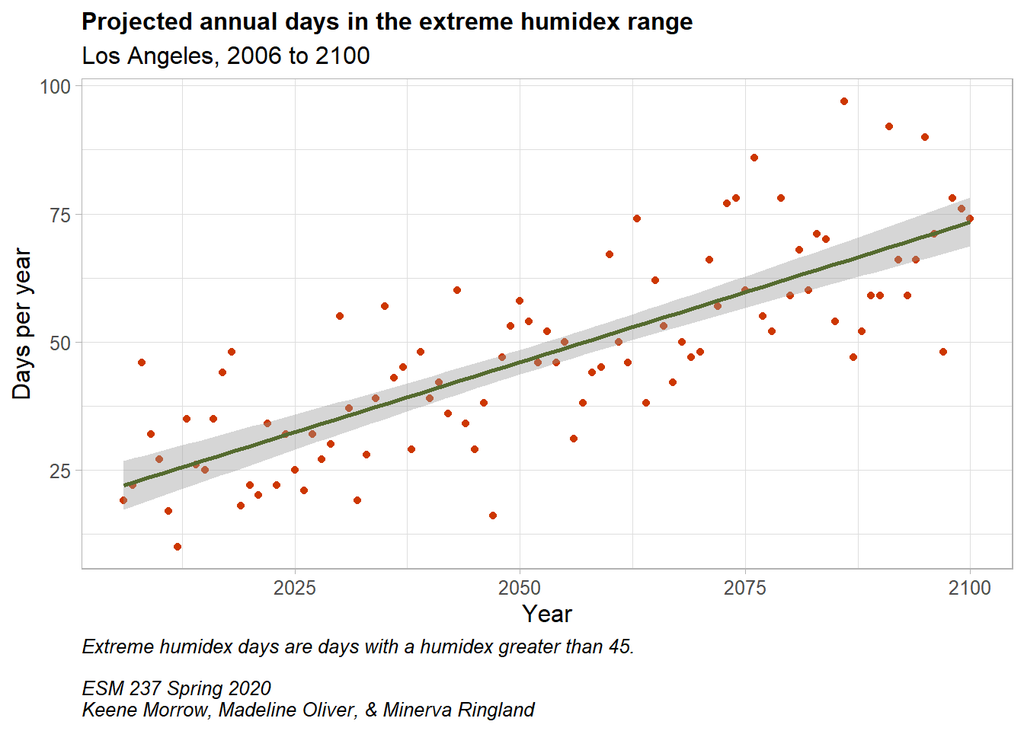

```
##
## Call:
## lm(formula = n ~ year, data = hx_45_count)
##
## Coefficients:
## (Intercept)         year
##  -1074.8667       0.5468
```

```
##       year            n
##  Min.   :2006   Min.   :10.00
##  1st Qu.:2030   1st Qu.:33.00
##  Median :2053   Median :47.00
##  Mean   :2053   Mean   :47.67
##  3rd Qu.:2076   3rd Qu.:59.00
##  Max.   :2100   Max.   :97.00
```

```
##          2.5 %    97.5 %
## year 0.4593308 0.6342302
```

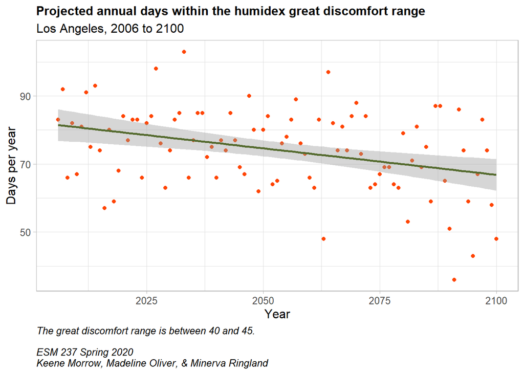

```
##
## Call:
## lm(formula = n ~ year, data = hx_40_count)
##
## Coefficients:
## (Intercept)         year
##    393.2867      -0.1554
```

```
##       year            n
##  Min.   :2006   Min.   : 36.00
##  1st Qu.:2030   1st Qu.: 66.00
##  Median :2053   Median : 75.00
##  Mean   :2053   Mean   : 74.16
##  3rd Qu.:2076   3rd Qu.: 83.00
##  Max.   :2100   Max.   :103.00
```

```
##          2.5 %      97.5 %
## year -0.240346 -0.07054429
```

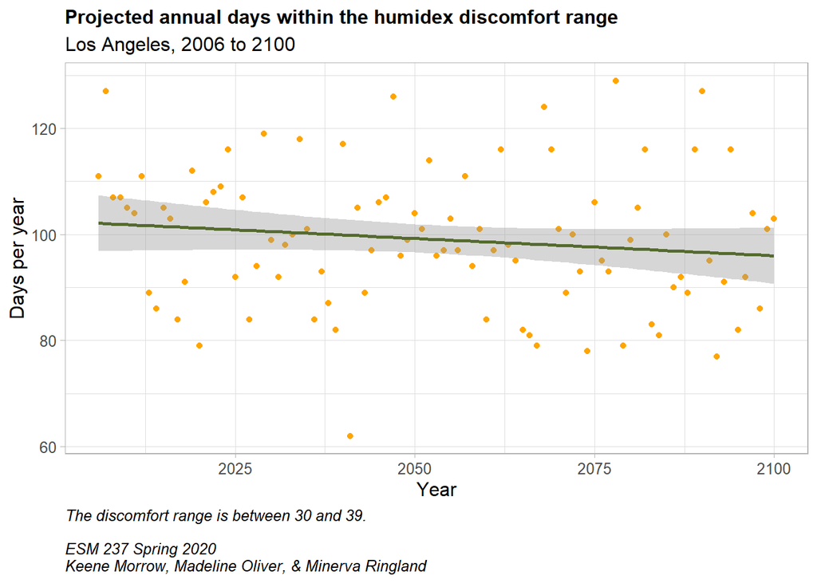

[output not shown]

[output not shown]

[output not shown]

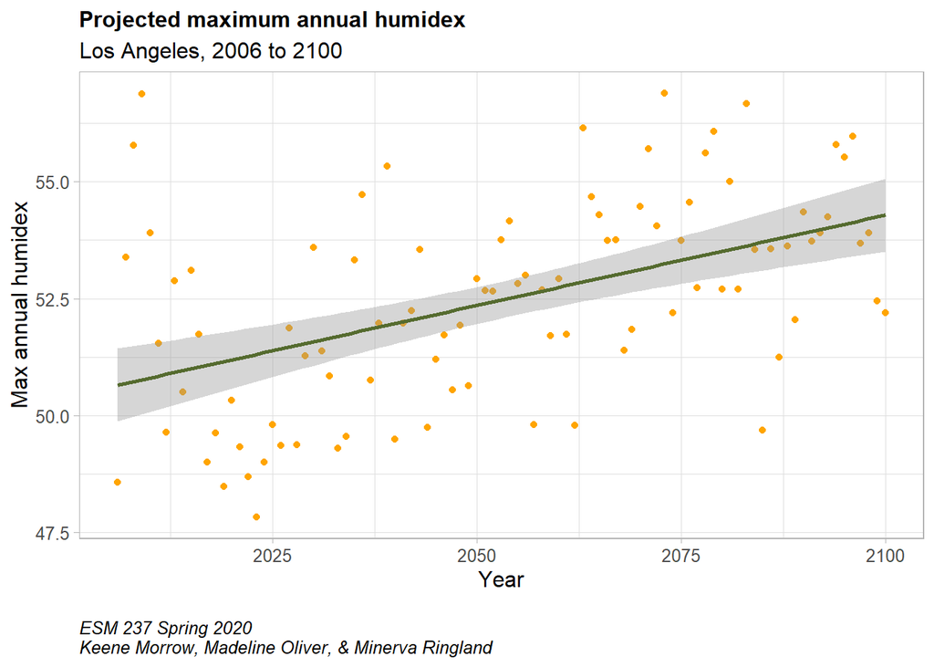

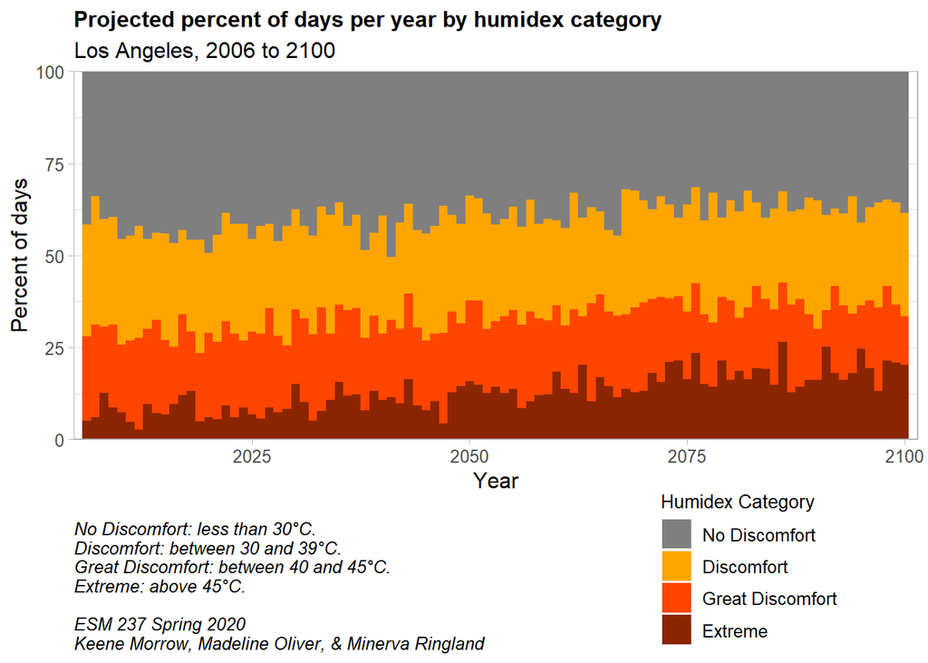

“Apparent temperatures greater than 80F are generally associated with some discomfort. Values approaching or exceeding 105F are considered life-threatening, with severe heat exhaustion or heatstroke possible if exposure is prolonged or physical activity high. The degree of heat stress may vary with age, health, and body characteristics.” https://climate.virginia.edu/apparent.htm

[figure not shown]

# Loop for climate model applications